# Project: Exploring eBay Car Sales Data

In this guided project, we'll work with a dataset of used cars from eBay Kleinanzeigen, a classifieds section of the German eBay website.

The dataset was originally scraped and uploaded to Kaggle by user orgesleka. The original dataset isn't available on Kaggle anymore, but you can find it here.

We've made a few modifications from the original dataset:

We sampled 50,000 data points from the full dataset, to ensure your code runs quickly in our hosted environment. We dirtied the dataset a bit to more closely resemble what you would expect from a scraped dataset (the version uploaded to Kaggle was cleaned to be easier to work with). Data dictionary for the dataset:

dateCrawled - When the ad was first crawled. All field-values are taken from this date. name - Name of the car. seller - Whether the seller is private or a dealer. offerType - The type of listing. price - The listed selling price of the car. abtest - Whether the listing is included in an A/B test. vehicleType - The type of vehicle. yearOfRegistration - The year in which the car was first registered. gearbox - The type of transmission. powerPS - The power of the car in PS. model - The car model name. odometer - How many kilometers the car has driven. monthOfRegistration - The month in which the car was first registered. fuelType - What type of fuel the car uses. brand - The brand of the car. notRepairedDamage - If the car has a damage which is not yet repaired. dateCreated - The date the eBay listing was created. nrOfPictures - The number of pictures in the ad. postalCode - The postal code for the location of the vehicle. lastSeenOnline - When the crawler saw this ad last online.

```python
import pandas as pd
import numpy as np
```

```python
autos = pd.read_csv('autos.csv', encoding = 'latin1')
```

```python
autos_shape = autos.shape
print(autos_shape)
```

```
(50000, 20)
```

```python
autos_head = autos.head
print(autos_head)
```

```
<bound method NDFrame.head of                dateCrawled                                               name  \
0      2016-03-26 17:47:46                   Peugeot_807_160_NAVTECH_ON_BOARD
1      2016-04-04 13:38:56         BMW_740i_4_4_Liter_HAMANN_UMBAU_Mega_Optik
2      2016-03-26 18:57:24                         Volkswagen_Golf_1.6_United
3      2016-03-12 16:58:10  Smart_smart_fortwo_coupe_softouch/F1/Klima/Pan...
4      2016-04-01 14:38:50  Ford_Focus_1_6_Benzin_TÜV_neu_ist_sehr_gepfleg...
...                    ...                                                ...
49995  2016-03-27 14:38:19   Audi_Q5_3.0_TDI_qu._S_tr.__Navi__Panorama__Xenon
49996  2016-03-28 10:50:25  Opel_Astra_F_Cabrio_Bertone_Edition___TÜV_neu+...
49997  2016-04-02 14:44:48                     Fiat_500_C_1.2_Dualogic_Lounge
49998  2016-03-08 19:25:42                 Audi_A3_2.0_TDI_Sportback_Ambition
49999  2016-03-14 00:42:12                                Opel_Vectra_1.6_16V

       seller offerType    price   abtest vehicleType  yearOfRegistration  \
0      privat   Angebot   $5,000  control         bus                2004
```

[output cut: 51 more lines]

```python
autos.info()
```

```
<class 'pandas.core.frame.DataFrame'>
RangeIndex: 50000 entries, 0 to 49999
Data columns (total 20 columns):
 #   Column               Non-Null Count  Dtype
---  ------               --------------  -----
 0   dateCrawled          50000 non-null  object
 1   name                 50000 non-null  object
 2   seller               50000 non-null  object
 3   offerType            50000 non-null  object
 4   price                50000 non-null  object
 5   abtest               50000 non-null  object
 6   vehicleType          44905 non-null  object
 7   yearOfRegistration   50000 non-null  int64
 8   gearbox              47320 non-null  object
 9   powerPS              50000 non-null  int64
 10  model                47242 non-null  object
 11  odometer             50000 non-null  object
 12  monthOfRegistration  50000 non-null  int64
 13  fuelType             45518 non-null  object
 14  brand                50000 non-null  object
 15  notRepairedDamage    40171 non-null  object
 16  dateCreated          50000 non-null  object
 17  nrOfPictures         50000 non-null  int64
 18  postalCode           50000 non-null  int64
 19  lastSeen             50000 non-null  object
dtypes: int64(5), object(15)
memory usage: 7.6+ MB
```

Some Observations The dataset has some missing values The column names use camelcase instead of Python's preferred snakecase Let's convert the column names from camelcase to snakecase and change some of the column names based on the data dictionary in order to be more descriptive

Cleaning Column Names

```python
columns = autos.columns.unique()
```

```python
print(columns)
```

```
Index(['dateCrawled', 'name', 'seller', 'offerType', 'price', 'abtest',
       'vehicleType', 'yearOfRegistration', 'gearbox', 'powerPS', 'model',
       'odometer', 'monthOfRegistration', 'fuelType', 'brand',
       'notRepairedDamage', 'dateCreated', 'nrOfPictures', 'postalCode',
       'lastSeen'],
      dtype='object')
```

```python
autos.rename(columns={'dateCrawled': 'date_crawled',
                'name': 'name', 'seller': 'seller',
                'offerType': 'offer_type', 'price': 'price',
                'abtest': 'ab_test', 'vehicleType': 'vehicle_type',
                'yearOfRegistration': 'registration_year',
                'gearbox': 'gear_box', 'powerPS': 'power_ps',
                'model': 'model', 'odometer': 'odometer',
                'monthOfRegistration': 'registration_month',
                'fuelType': 'fuel_type', 'brand': 'brand',
                'notRepairedDamage': 'unrepaired_damage',
                'dateCreated': 'ad_created',
                'nrOfPictures': 'num_of_photos',
                'postalCode': 'postal_code', 'lastSeen': 'last_seen'}, inplace=True)
```

```python
autos_head = autos.head
print(autos_head)
```

```
<bound method NDFrame.head of               date_crawled                                               name  \
0      2016-03-26 17:47:46                   Peugeot_807_160_NAVTECH_ON_BOARD
1      2016-04-04 13:38:56         BMW_740i_4_4_Liter_HAMANN_UMBAU_Mega_Optik
2      2016-03-26 18:57:24                         Volkswagen_Golf_1.6_United
3      2016-03-12 16:58:10  Smart_smart_fortwo_coupe_softouch/F1/Klima/Pan...
4      2016-04-01 14:38:50  Ford_Focus_1_6_Benzin_TÜV_neu_ist_sehr_gepfleg...
...                    ...                                                ...
49995  2016-03-27 14:38:19   Audi_Q5_3.0_TDI_qu._S_tr.__Navi__Panorama__Xenon
49996  2016-03-28 10:50:25  Opel_Astra_F_Cabrio_Bertone_Edition___TÜV_neu+...
49997  2016-04-02 14:44:48                     Fiat_500_C_1.2_Dualogic_Lounge
49998  2016-03-08 19:25:42                 Audi_A3_2.0_TDI_Sportback_Ambition
49999  2016-03-14 00:42:12                                Opel_Vectra_1.6_16V

       seller offer_type    price  ab_test vehicle_type  registration_year  \
0      privat    Angebot   $5,000  control          bus               2004
```

[output cut: 51 more lines]

Initial Exploration and Cleaning

```python
describe = autos.describe( include = 'all')
print(describe)
```

```
               date_crawled         name  seller offer_type  price ab_test  \
count                 50000        50000   50000      50000  50000   50000
unique                48213        38754       2          2   2357       2
top     2016-04-02 11:37:04  Ford_Fiesta  privat    Angebot     $0    test
freq                      3           78   49999      49999   1421   25756
mean                    NaN          NaN     NaN        NaN    NaN     NaN
std                     NaN          NaN     NaN        NaN    NaN     NaN
min                     NaN          NaN     NaN        NaN    NaN     NaN
25%                     NaN          NaN     NaN        NaN    NaN     NaN
50%                     NaN          NaN     NaN        NaN    NaN     NaN
75%                     NaN          NaN     NaN        NaN    NaN     NaN
max                     NaN          NaN     NaN        NaN    NaN     NaN

       vehicle_type  registration_year gear_box      power_ps  model  \
count         44905       50000.000000    47320  50000.000000  47242
unique            8                NaN        2           NaN    245
top       limousine                NaN  manuell           NaN   golf
freq          12859                NaN    36993           NaN   4024
mean            NaN        2005.073280      NaN    116.355920    NaN
std             NaN         105.712813      NaN    209.216627    NaN
min             NaN        1000.000000      NaN      0.000000    NaN
25%             NaN        1999.000000      NaN     70.000000    NaN
50%             NaN        2003.000000      NaN    105.000000    NaN
75%             NaN        2008.000000      NaN    150.000000    NaN
max             NaN        9999.000000      NaN  17700.000000    NaN

         odometer  registration_month fuel_type       brand unrepaired_damage  \
count       50000        50000.000000     45518       50000             40171
unique         13                 NaN         7          40                 2
top     150,000km                 NaN    benzin  volkswagen              nein
freq        32424                 NaN     30107       10687             35232
mean          NaN            5.723360       NaN         NaN               NaN
std           NaN            3.711984       NaN         NaN               NaN
min           NaN            0.000000       NaN         NaN               NaN
25%           NaN            3.000000       NaN         NaN               NaN
50%           NaN            6.000000       NaN         NaN               NaN
75%           NaN            9.000000       NaN         NaN               NaN
max           NaN           12.000000       NaN         NaN               NaN

                 ad_created  num_of_photos   postal_code            last_seen
count                 50000        50000.0  50000.000000                50000
unique                   76            NaN           NaN                39481
top     2016-04-03 00:00:00            NaN           NaN  2016-04-07 06:17:27
freq                   1946            NaN           NaN                    8
mean                    NaN            0.0  50813.627300                  NaN
std                     NaN            0.0  25779.747957                  NaN
min                     NaN            0.0   1067.000000                  NaN
25%                     NaN            0.0  30451.000000                  NaN
50%                     NaN            0.0  49577.000000                  NaN
75%                     NaN            0.0  71540.000000                  NaN
max                     NaN            0.0  99998.000000                  NaN
```

```python
autos['price'] = autos.price.str.replace('\D', '', regex = True).astype(float)
```

```python
autos['odometer'] = autos.odometer.str.replace('\D', '', regex = True).astype(float)
```

```python
autos.rename(columns = {'odometer': 'odometer_km'}, inplace = True)
```

Exploring the Odometer and Price Columns

```python
print(autos['odometer_km'].unique().shape)
print(autos['price'].unique().shape)
```

```
(13,)
(2357,)
```

```python
print(autos['price'].describe())
```

```
count    5.000000e+04
mean     9.840044e+03
std      4.811044e+05
min      0.000000e+00
25%      1.100000e+03
50%      2.950000e+03
75%      7.200000e+03
max      1.000000e+08
Name: price, dtype: float64
```

```python
df = autos.copy()
df[df.price.between(0, 99_000, inclusive = 'neither')].shape
(48522, 20)

df = df[df.price.between(0, 99_000, inclusive = 'neither')]

df.price.describe()
```

```
count    48522.000000
mean      5747.850274
std       7466.499649
min          1.000000
25%       1200.000000
50%       3000.000000
75%       7450.000000
max      98500.000000
Name: price, dtype: float64
```

The price stats now looks reasonable.

```python
print(autos['odometer_km'].describe())
```

```
count     50000.000000
mean     125732.700000
std       40042.211706
min        5000.000000
25%      125000.000000
50%      150000.000000
75%      150000.000000
max      150000.000000
Name: odometer_km, dtype: float64
```

```python
print(autos['odometer_km'].value_counts())
print(autos['price'].value_counts())
```

```
150000.0    32424
125000.0     5170
100000.0     2169
90000.0      1757
80000.0      1436
70000.0      1230
60000.0      1164
50000.0      1027
5000.0        967
40000.0       819
30000.0       789
20000.0       784
10000.0       264
Name: odometer_km, dtype: int64
0.0        1421
500.0       781
1500.0      734
2500.0      643
1000.0      639
           ...
414.0         1
79933.0       1
5198.0        1
18890.0       1
16995.0       1
Name: price, Length: 2357, dtype: int64
```

Exploring the Date Columns

```python
print(autos.columns)
autos.rename(columns={'dateCrawled': 'date_crawled'}, inplace=True)
print(autos.columns)
```

```
Index(['date_crawled', 'name', 'seller', 'offer_type', 'price', 'ab_test',
       'vehicle_type', 'registration_year', 'gear_box', 'power_ps', 'model',
       'odometer_km', 'registration_month', 'fuel_type', 'brand',
       'unrepaired_damage', 'ad_created', 'num_of_photos', 'postal_code',
       'last_seen'],
      dtype='object')
Index(['date_crawled', 'name', 'seller', 'offer_type', 'price', 'ab_test',
       'vehicle_type', 'registration_year', 'gear_box', 'power_ps', 'model',
       'odometer_km', 'registration_month', 'fuel_type', 'brand',
       'unrepaired_damage', 'ad_created', 'num_of_photos', 'postal_code',
       'last_seen'],
      dtype='object')
```

```python
autos[['date_crawled','ad_created','last_seen']][0:5]
```

|  | date_crawled | ad_created | last_seen |
| --- | --- | --- | --- |
| 0 | 2016-03-26 17:47:46 | 2016-03-26 00:00:00 | 2016-04-06 06:45:54 |
| 1 | 2016-04-04 13:38:56 | 2016-04-04 00:00:00 | 2016-04-06 14:45:08 |
| 2 | 2016-03-26 18:57:24 | 2016-03-26 00:00:00 | 2016-04-06 20:15:37 |
| 3 | 2016-03-12 16:58:10 | 2016-03-12 00:00:00 | 2016-03-15 03:16:28 |
| 4 | 2016-04-01 14:38:50 | 2016-04-01 00:00:00 | 2016-04-01 14:38:50 |

```python
df[['date_crawled','ad_created','last_seen']][0:5].dtypes
```

```
date_crawled    object
ad_created      object
last_seen       object
dtype: object
```

```python
date_cols = ['date_crawled','ad_created','last_seen']

for col in date_cols:
    df[col] = df[col].str[:10]
```

```python
df.date_crawled.value_counts(normalize = True, dropna = False).sort_index()
```

```
2016-03-05    0.025308
2016-03-06    0.014035
2016-03-07    0.036046
2016-03-08    0.033284
2016-03-09    0.033098
2016-03-10    0.032212
2016-03-11    0.032604
2016-03-12    0.036932
2016-03-13    0.015684
2016-03-14    0.036581
2016-03-15    0.034273
2016-03-16    0.029615
2016-03-17    0.031635
2016-03-18    0.012881
2016-03-19    0.034809
2016-03-20    0.037900
2016-03-21    0.037364
2016-03-22    0.032913
2016-03-23    0.032233
2016-03-24    0.029348
2016-03-25    0.031594
2016-03-26    0.032192
2016-03-27    0.031079
2016-03-28    0.034850
2016-03-29    0.034129
2016-03-30    0.033655
2016-03-31    0.031841
2016-04-01    0.033634
2016-04-02    0.035510
2016-04-03    0.038601
2016-04-04    0.036499
2016-04-05    0.013087
2016-04-06    0.003174
2016-04-07    0.001401
Name: date_crawled, dtype: float64
```

```python
df.ad_created.value_counts(normalize = True, dropna = False).sort_index()
```

```
2015-06-11    0.000021
2015-08-10    0.000021
2015-09-09    0.000021
2015-11-10    0.000021
2015-12-05    0.000021
                ...
2016-04-03    0.038848
2016-04-04    0.036870
2016-04-05    0.011809
2016-04-06    0.003256
2016-04-07    0.001257
Name: ad_created, Length: 76, dtype: float64
```

```python
df.last_seen.value_counts(normalize = True, dropna = False).sort_index()
```

```
2016-03-05    0.001072
2016-03-06    0.004328
2016-03-07    0.005400
2016-03-08    0.007419
2016-03-09    0.009583
2016-03-10    0.010676
2016-03-11    0.012386
2016-03-12    0.023804
2016-03-13    0.008903
2016-03-14    0.012613
2016-03-15    0.015890
2016-03-16    0.016446
2016-03-17    0.028111
2016-03-18    0.007337
2016-03-19    0.015848
2016-03-20    0.020650
2016-03-21    0.020630
2016-03-22    0.021392
2016-03-23    0.018528
2016-03-24    0.019744
2016-03-25    0.019228
2016-03-26    0.016755
2016-03-27    0.015642
2016-03-28    0.020857
2016-03-29    0.022361
2016-03-30    0.024793
2016-03-31    0.023804
2016-04-01    0.022814
2016-04-02    0.024917
2016-04-03    0.025205
2016-04-04    0.024504
2016-04-05    0.124624
2016-04-06    0.221858
2016-04-07    0.131878
Name: last_seen, dtype: float64
```

Dealing with Incorrect Registration Year Data

```python
autos[['registration_year']][0:5]
```

|  | registration_year |
| --- | --- |
| 0 | 2004 |
| 1 | 1997 |
| 2 | 2009 |
| 3 | 2007 |
| 4 | 2003 |

```python
df.registration_year.tail()
```

```
49995    2011
49996    1996
49997    2014
49998    2013
49999    1996
Name: registration_year, dtype: int64
```

```python
df = autos.copy()
autos['registration_year'].shape
```

```
(50000,)
```

```python
df.registration_year.min(), df.registration_year.max()
```

```
(1000, 9999)
```

```python
df.registration_year.describe()
```

```
count    50000.000000
mean      2005.073280
std        105.712813
min       1000.000000
25%       1999.000000
50%       2003.000000
75%       2008.000000
max       9999.000000
Name: registration_year, dtype: float64
```

Number of listings with cars that fall outside 1900 - 2016 interval

```python
#df[df.registration_year.between(1900,2016,inclusive='neither')].shape
#df = df[df.registration_year.between(1990,2016,inclusive = 'neither')]
#Remove the values outside those upper and lower bounds and calculate the distribution of the remaining values using
len(df[(df.registration_year < 1900) & (df.registration_year > 2016)])
```

```
0
```

## Exploring Price by Brand

```python
Unique_brands = df['brand'].unique()

Unique_brands
```

```
array(['peugeot', 'bmw', 'volkswagen', 'smart', 'ford', 'chrysler',
       'seat', 'renault', 'mercedes_benz', 'audi', 'sonstige_autos',
       'opel', 'mazda', 'porsche', 'mini', 'toyota', 'dacia', 'nissan',
       'jeep', 'saab', 'volvo', 'mitsubishi', 'jaguar', 'fiat', 'skoda',
       'subaru', 'kia', 'citroen', 'chevrolet', 'hyundai', 'honda',
       'daewoo', 'suzuki', 'trabant', 'land_rover', 'alfa_romeo', 'lada',
       'rover', 'daihatsu', 'lancia'], dtype=object)
```

```python
mean_price_by_brand = df.groupby('brand').price.mean().sort_values(ascending=False)
print(mean_price_by_brand)
```

```
brand
porsche           44537.979592
citroen           42657.463623
sonstige_autos    38300.840659
volvo             31689.908096
mercedes_benz     29511.955429
land_rover        18934.272727
fiat              12134.206422
jeep              11363.209091
jaguar            11076.506494
mini              10392.393868
audi               8965.560355
bmw                8252.918954
ford               7105.662547
chevrolet          6432.929329
volkswagen         6384.167400
skoda              6305.044529
dacia              5897.736434
kia                5707.325843
hyundai            5316.754098
opel               5106.092657
toyota             5097.941653
nissan             4588.879310
seat               4219.431456
suzuki             4038.952218
mazda              3962.542933
alfa_romeo         3943.562310
honda              3889.859649
subaru             3769.981651
smart              3482.971469
mitsubishi         3314.049261
chrysler           3286.055249
saab               3143.700000
lancia             3070.350877
peugeot            3010.868819
lada               2476.903226
renault            2351.301997
daihatsu           1552.093750
trabant            1543.525641
rover              1494.521739
daewoo             1038.354430
Name: price, dtype: float64
```

```python
print(f'Top20 brands by price:/n{mean_price_by_brand.head(20)}')
```

```
Top20 brands by price:/nbrand
porsche           44537.979592
citroen           42657.463623
sonstige_autos    38300.840659
volvo             31689.908096
mercedes_benz     29511.955429
land_rover        18934.272727
fiat              12134.206422
jeep              11363.209091
jaguar            11076.506494
mini              10392.393868
audi               8965.560355
bmw                8252.918954
ford               7105.662547
chevrolet          6432.929329
volkswagen         6384.167400
skoda              6305.044529
dacia              5897.736434
kia                5707.325843
hyundai            5316.754098
opel               5106.092657
Name: price, dtype: float64
```

[figure not shown]

```python
mean_price_by_brand.head(20).sort_values().plot(kind = 'barh', title = 'Top10 brands by mean price');
```

```python
print(f'Bottom20brands by mean price:/n{mean_price_by_brand.tail(20)}')
```

```
Bottom20brands by mean price:/nbrand
toyota        5097.941653
nissan        4588.879310
seat          4219.431456
suzuki        4038.952218
mazda         3962.542933
alfa_romeo    3943.562310
honda         3889.859649
subaru        3769.981651
smart         3482.971469
mitsubishi    3314.049261
chrysler      3286.055249
saab          3143.700000
lancia        3070.350877
peugeot       3010.868819
lada          2476.903226
renault       2351.301997
daihatsu      1552.093750
trabant       1543.525641
rover         1494.521739
daewoo        1038.354430
Name: price, dtype: float64
```

[figure not shown]

```python
mean_price_by_brand.tail(20).sort_values().plot(kind='barh',title = 'Top10 brands by mean price')
```

## Storing Aggregate Data in a DataFrame

```python
mean_price = pd.DataFrame(mean_price_by_brand)
```

```python
mean_price.columns = ['mean_price']
```

```python
mean_price
```

| brand | mean_price |
| --- | --- |
| porsche | 44537.979592 |
| citroen | 42657.463623 |
| sonstige_autos | 38300.840659 |
| volvo | 31689.908096 |
| mercedes_benz | 29511.955429 |
| land_rover | 18934.272727 |
| fiat | 12134.206422 |
| jeep | 11363.209091 |
| jaguar | 11076.506494 |
| mini | 10392.393868 |
| audi | 8965.560355 |
| bmw | 8252.918954 |
| ford | 7105.662547 |
| chevrolet | 6432.929329 |
| volkswagen | 6384.167400 |
| skoda | 6305.044529 |
| dacia | 5897.736434 |
| kia | 5707.325843 |
| hyundai | 5316.754098 |
| opel | 5106.092657 |
| toyota | 5097.941653 |
| nissan | 4588.879310 |
| seat | 4219.431456 |
| suzuki | 4038.952218 |
| mazda | 3962.542933 |
| alfa_romeo | 3943.562310 |
| honda | 3889.859649 |
| subaru | 3769.981651 |
| smart | 3482.971469 |
| mitsubishi | 3314.049261 |
| chrysler | 3286.055249 |
| saab | 3143.700000 |
| lancia | 3070.350877 |
| peugeot | 3010.868819 |
| lada | 2476.903226 |
| renault | 2351.301997 |
| daihatsu | 1552.093750 |
| trabant | 1543.525641 |
| rover | 1494.521739 |
| daewoo | 1038.354430 |

```python
mean_price_milage_by_brand = df.groupby('brand')[['price','odometer_km']].mean().sort_values(by = 'price', ascending = False)
```

```python
mean_price_milage_by_brand.columns = ['mean_price','mean_odometer_km']
```

```python
mean_price_milage_by_brand
```

| brand | mean_price | mean_odometer_km |
| --- | --- | --- |
| porsche | 44537.979592 | 97363.945578 |
| citroen | 42657.463623 | 119764.621969 |
| sonstige_autos | 38300.840659 | 87188.644689 |
| volvo | 31689.908096 | 138632.385120 |
| mercedes_benz | 29511.955429 | 130886.142797 |
| land_rover | 18934.272727 | 118333.333333 |
| fiat | 12134.206422 | 117037.461774 |
| jeep | 11363.209091 | 126409.090909 |
| jaguar | 11076.506494 | 121298.701299 |
| mini | 10392.393868 | 89375.000000 |
| audi | 8965.560355 | 129643.941163 |
| bmw | 8252.918954 | 132521.643028 |
| ford | 7105.662547 | 124131.934464 |
| chevrolet | 6432.929329 | 99522.968198 |
| volkswagen | 6384.167400 | 128955.272761 |
| skoda | 6305.044529 | 110947.837150 |
| dacia | 5897.736434 | 84728.682171 |
| kia | 5707.325843 | 112640.449438 |
| hyundai | 5316.754098 | 106782.786885 |
| opel | 5106.092657 | 129298.663248 |
| toyota | 5097.941653 | 115988.654781 |
| nissan | 4588.879310 | 118978.779841 |
| seat | 4219.431456 | 122061.636557 |
| suzuki | 4038.952218 | 109334.470990 |
| mazda | 3962.542933 | 125132.100396 |
| alfa_romeo | 3943.562310 | 131109.422492 |
| honda | 3889.859649 | 123709.273183 |
| subaru | 3769.981651 | 124449.541284 |
| smart | 3482.971469 | 100756.062767 |
| mitsubishi | 3314.049261 | 126293.103448 |
| chrysler | 3286.055249 | 133149.171271 |
| saab | 3143.700000 | 143750.000000 |
| lancia | 3070.350877 | 123157.894737 |
| peugeot | 3010.868819 | 127352.335165 |
| lada | 2476.903226 | 86774.193548 |
| renault | 2351.301997 | 128223.793677 |
| daihatsu | 1552.093750 | 114843.750000 |
| trabant | 1543.525641 | 59358.974359 |
| rover | 1494.521739 | 136449.275362 |
| daewoo | 1038.354430 | 121708.860759 |

```python
print(f'mean_price_milage_by_brand:\n{mean_price_milage_by_brand.head(10)}')
```

```
mean_price_milage_by_brand:
                  mean_price  mean_odometer_km
brand
porsche         44537.979592      97363.945578
citroen         42657.463623     119764.621969
sonstige_autos  38300.840659      87188.644689
volvo           31689.908096     138632.385120
mercedes_benz   29511.955429     130886.142797
land_rover      18934.272727     118333.333333
fiat            12134.206422     117037.461774
jeep            11363.209091     126409.090909
jaguar          11076.506494     121298.701299
mini            10392.393868      89375.000000
```

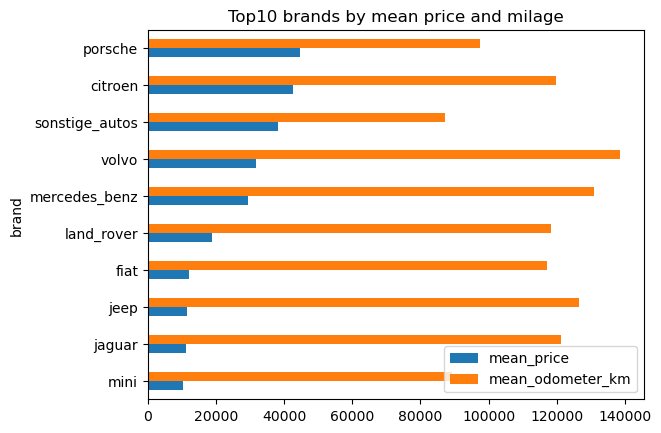

```python
mean_price_milage_by_brand.head(10).sort_values(by = 'mean_price').plot(kind = 'barh', title = 'Top10 brands by mean price and milage');
```

```python
print(f'Bottom10 brands by mean price and milage:\n{mean_price_milage_by_brand.tail(10)}')
```

```
Bottom10 brands by mean price and milage:
           mean_price  mean_odometer_km
brand
chrysler  3286.055249     133149.171271
saab      3143.700000     143750.000000
lancia    3070.350877     123157.894737
peugeot   3010.868819     127352.335165
lada      2476.903226      86774.193548
renault   2351.301997     128223.793677
daihatsu  1552.093750     114843.750000
trabant   1543.525641      59358.974359
rover     1494.521739     136449.275362
daewoo    1038.354430     121708.860759
```

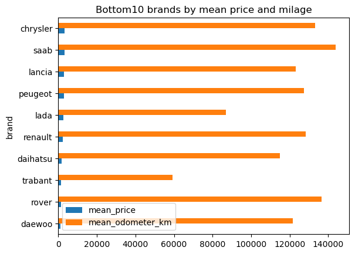

```python
mean_price_milage_by_brand.tail(10).sort_values(by = 'mean_price').plot(kind = 'barh', title = 'Bottom10 brands by mean price and milage');
```